# Practical Machine Learning Course Project

Manish Jariwala

Saturday, May 23, 2015

### Synposis

Gellersen et. al. conducted a research on activity recognition to answer the “how (well)” an health related activity has been performed. They capture data through sensors during weight lifting exercises.

The data was captured through accelometers on the belt, forearm, arm and dumbbell of 6 participants. They were asked to perform barbell lifts correctly and incorrectly in 5 different ways.

The assignment requires to show the model selection, cross validation and prediction on classe variable.

### Download Data and important data

Load all library, and import data from the link provided for the assignment

```r
#Inlcude require libary
library(AppliedPredictiveModeling)
library(caret)
library(rattle)
```

```r
library(rpart.plot)
library(randomForest)
# download files in current working directory
download.file(url="https://d396qusza40orc.cloudfront.net/predmachlearn/pml-training.csv",destfile="pml-training.csv",method = "curl" )
download.file(url="https://d396qusza40orc.cloudfront.net/predmachlearn/pml-testing.csv",destfile="pml-testing.csv", method= "curl")
#Import the data, while replacing null values with NA
im_training <- read.csv("pml-training.csv", na.strings=c("NA",""),header=TRUE)
dim(im_training)
```

```
## [1] 19622   160
```

```r
im_testing <- read.csv("pml-testing.csv", na.strings=c("NA",""),header=TRUE)
dim(im_testing)
```

```
## [1]  20 160
```

### Algorithm

Using data partition create a training and testing data set out of the training dataset that was downloaded.

```r
# Seperate data into training and testing data set from training data that was downloaded
inTrain = createDataPartition(y=im_cleanTraining$classe, p=0.7, list=FALSE)
training = im_cleanTraining[inTrain,]
testing = im_cleanTraining[-inTrain,]
```

[output not shown]

The two algorithm chosen from caret package are classification tress and random forests

#### Classificaiton Tree

Run classification with preprocessing and cross validation.

```r
set.seed(2222)
modFitc <- train(training$classe ~ ., preProcess=c("center", "scale"), trControl=trainControl(method = "cv", number = 4), data = training, method = "rpart")
print(modFitc, digits=3)
```

```
## CART
##
## 13737 samples
##    52 predictor
##     5 classes: 'A', 'B', 'C', 'D', 'E'
##
## Pre-processing: centered, scaled
## Resampling: Cross-Validated (4 fold)
##
## Summary of sample sizes: 10303, 10301, 10303, 10304
##
## Resampling results across tuning parameters:
##
##   cp      Accuracy  Kappa   Accuracy SD  Kappa SD
##   0.0327  0.549     0.4192  0.0387       0.0576
##   0.0607  0.399     0.1793  0.0648       0.1089
##   0.1159  0.325     0.0621  0.0472       0.0717
##
## Accuracy was used to select the optimal model using  the largest value.
## The final value used for the model was cp = 0.0327.
```

```r
print(modFitc$finalModel, digits=3)
```

```
## n= 13737
##
## node), split, n, loss, yval, (yprob)
##       * denotes terminal node
##
##  1) root 13737 9830 A (0.28 0.19 0.17 0.16 0.18)
##    2) roll_belt< 1.06 12582 8680 A (0.31 0.21 0.19 0.18 0.11)
##      4) pitch_forearm< -1.58 1136    7 A (0.99 0.0062 0 0 0) *
##      5) pitch_forearm>=-1.58 11446 8680 A (0.24 0.23 0.21 0.2 0.12)
##       10) magnet_dumbbell_y< 0.653 9604 6900 A (0.28 0.18 0.24 0.19 0.11)
##         20) roll_forearm< 0.832 5977 3560 A (0.4 0.18 0.19 0.17 0.062) *
##         21) roll_forearm>=0.832 3627 2420 C (0.078 0.18 0.33 0.23 0.18) *
##       11) magnet_dumbbell_y>=0.653 1842  911 B (0.037 0.51 0.041 0.23 0.19) *
##    3) roll_belt>=1.06 1155    8 E (0.0069 0 0 0 0.99) *
```

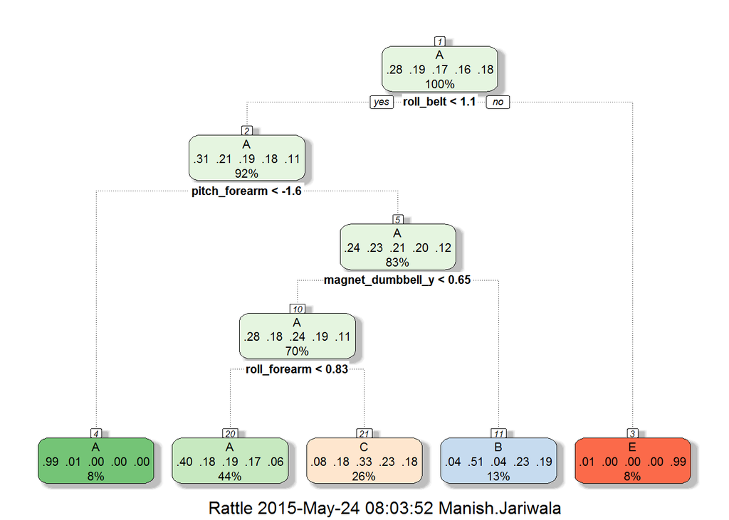

```r
fancyRpartPlot(modFitc$finalModel)
```

Execute against the testing model

```r
predictions <- predict(modFitc, newdata=testing)
print(confusionMatrix(predictions, testing$classe), digits=4)
```

```
## Confusion Matrix and Statistics
##
##           Reference
## Prediction    A    B    C    D    E
##          A 1524  493  477  431  148
##          B   26  371   34  155  153
##          C  118  275  515  378  297
##          D    0    0    0    0    0
##          E    6    0    0    0  484
##
## Overall Statistics
##
##                Accuracy : 0.4918
##                  95% CI : (0.4789, 0.5046)
##     No Information Rate : 0.2845
##     P-Value [Acc > NIR] : < 2.2e-16
##
##                   Kappa : 0.3356
##  Mcnemar's Test P-Value : NA
##
## Statistics by Class:
##
##                      Class: A Class: B Class: C Class: D Class: E
## Sensitivity            0.9104  0.32572  0.50195   0.0000  0.44732
## Specificity            0.6322  0.92246  0.78020   1.0000  0.99875
## Pos Pred Value         0.4959  0.50203  0.32533      NaN  0.98776
## Neg Pred Value         0.9467  0.85076  0.88122   0.8362  0.88916
## Prevalence             0.2845  0.19354  0.17434   0.1638  0.18386
## Detection Rate         0.2590  0.06304  0.08751   0.0000  0.08224
## Detection Prevalence   0.5222  0.12557  0.26899   0.0000  0.08326
## Balanced Accuracy      0.7713  0.62409  0.64108   0.5000  0.72304
```

Unfortunately, classification method resulted in low accuracy rate. So, we will move on to random forest method.

#### Random forest

First train on the training data using random forest method

```r
# Training data based on training data
set.seed(222)
modFit <- train(training$classe ~ ., data = training, method = "rf",trControl=trainControl(method = "cv", number = 4))
print(modFit,3)
saveRDS(model, "rfmodel.RDS")
```

[output not shown]

Run it against the testing data

```r
#Run against testing data
modFit <- readRDS("rfmodel.RDS")
predictions <- predict(modFit, newdata=testing)
print(confusionMatrix(predictions, testing$classe), digits=4)
```

```
## Confusion Matrix and Statistics
##
##           Reference
## Prediction    A    B    C    D    E
##          A 1674    0    0    0    0
##          B    0 1139    1    0    0
##          C    0    0 1024    6    0
##          D    0    0    1  958    0
##          E    0    0    0    0 1082
##
## Overall Statistics
##
##                Accuracy : 0.9986
##                  95% CI : (0.9973, 0.9994)
##     No Information Rate : 0.2845
##     P-Value [Acc > NIR] : < 2.2e-16
##
##                   Kappa : 0.9983
##  Mcnemar's Test P-Value : NA
##
## Statistics by Class:
##
##                      Class: A Class: B Class: C Class: D Class: E
## Sensitivity            1.0000   1.0000   0.9981   0.9938   1.0000
## Specificity            1.0000   0.9998   0.9988   0.9998   1.0000
## Pos Pred Value         1.0000   0.9991   0.9942   0.9990   1.0000
## Neg Pred Value         1.0000   1.0000   0.9996   0.9988   1.0000
## Prevalence             0.2845   0.1935   0.1743   0.1638   0.1839
## Detection Rate         0.2845   0.1935   0.1740   0.1628   0.1839
## Detection Prevalence   0.2845   0.1937   0.1750   0.1630   0.1839
## Balanced Accuracy      1.0000   0.9999   0.9984   0.9968   1.0000
```

Now run it against the testing data provided for the assignment.

```r
 finalanswer <- predict(modFit, newdata = im_testing)
print(finalanswer)
```

```
##  [1] B A B A A E D B A A B C B A E E A B B B
## Levels: A B C D E
```

#### Error rate out of sample

The error rate out of the sample is less than 1%, which is quite good for such analysis.